## Máster en Data Science

### Machine Learning

Contacto: angel.blanco@cunef.edu

# **Valores missing, outlier y correlaciones**

En este notebook se realiza el estudio y preprocesamiento de las variables numéricas y categoricas. Se realizarán los siguientes pasos:

1. Cambio de tipos de variables.
2. Separación estratificada en train y test.
3. Análisis de cada variable con gráficos descriptivos.
4. Para variables numericas: correlaciones de pearnson, estudio de outliers y estudio de valores missing.
5. Para variables categoricas: relleno de valores missing, estudio de correlaciones con vCramer.

Para los valores outlier por columnas, se tendrá en cuenta los gráficos:

[figure not shown]

Dentro del tratamiento de los valores missing, se elegirá alguno de los siguientes métodos:

[figure not shown]

#### Librerías

```python
import os
from pathlib import Path

# Cambiamos el directory al root del proyecto, no a `notebooks`
current_dir = Path.cwd()

if current_dir.name == "notebooks":
    os.chdir(current_dir.parent)

#Procesamiento
import pandas as pd
import numpy as np

# Gráficos
import seaborn as sns
import matplotlib.pyplot as plt
import plotly.express as px

# Otras
import scipy.stats as ss
from sklearn.model_selection import train_test_split

# Opciones de visualización
pd.set_option('display.max_columns', 500)
pd.set_option('display.max_rows', 5000)

# Omitir warnings
import warnings
warnings.filterwarnings('ignore')

# Funciones
from src.plots import plot_feature, get_corr_matrix

from src.analysis import (
    get_deviation_of_mean_perc,
    get_percent_null_values_target,
    cramers_v
)
from src.data_processing import  impute_na

from src.data import write_csv
from src.const import variable_types
```

#### Carga de datos del preprocesado inicial

```python
pd_fraud = pd.read_csv("data/preprocessed/pd_data_initial_preprocessing.csv")
```

Creación de una lista con las variables categóricas y cambio a formato category

```python
# Agrupación de variables
cat_vars = variable_types['categoricals']

# Cambio del tipo
pd_fraud[cat_vars] = pd_fraud[cat_vars].astype("category")
```

Agrupación de las numéricas enteras y cambio a tipo float para que funcionen bien los gráficos

```python
# Lista de variables a cambiar
to_float = [
    'prev_address_months_count',
    'current_address_months_count',
    'zip_count_4w',
    'bank_branch_count_8w',
    'credit_risk_score',
]

# Cambio de tipo
pd_fraud[to_float] = pd_fraud[to_float].astype(float)
```

```python
# Comprobación
pd_fraud.dtypes
```

```
fraud_bool                             int64
income                               float64
device_fraud_count                     int64
device_distinct_emails_8w              int64
keep_alive_session                     int64
device_os                           category
session_length_in_minutes            float64
source                              category
foreign_request                        int64
proposed_credit_limit                float64
has_other_cards                        int64
bank_months_count                      int64
phone_mobile_valid                     int64
phone_home_valid                       int64
housing_status                      category
email_is_free                          int64
credit_risk_score                    float64
employment_status                   category
date_of_birth_distinct_emails_4w       int64
bank_branch_count_8w                 float64
velocity_4w                          float64
velocity_24h                         float64
velocity_6h                          float64
zip_count_4w                         float64
payment_type                        category
intended_balcon_amount               float64
days_since_request                   float64
customer_age                           int64
current_address_months_count         float64
prev_address_months_count            float64
name_email_similarity                float64
month                                  int64
dtype: object
```

#### Separación en train y test estratificado

```python
# Conteo de porcentaje normalizado para el gráfico
pd_plot_fraud_bool = (
    pd_fraud['fraud_bool']
        .value_counts(normalize=True)
        .mul(100)
        .rename('percent')
        .reset_index()
)

# Unión de dataframes de conteo y fraud_bool a secas
pd_plot_fraud_bool_conteo = pd_fraud['fraud_bool'].value_counts().reset_index()
pd_plot_fraud_bool_pc = pd.merge(pd_plot_fraud_bool, pd_plot_fraud_bool_conteo, left_index=True, right_index=True, how='inner')
pd_plot_fraud_bool_pc


# Construcción de histograma
fig = px.histogram(pd_plot_fraud_bool_pc, x=pd_plot_fraud_bool_pc.index, y=['percent'])
fig.update_layout(title='Porcentaje de fraudes', xaxis_title='Fraude', yaxis_title='Porcentaje')

fig.show()
```

[interactive chart not shown]

```python
# Split de train y test estratificado al 20%
X_pd_fraud, X_pd_fraud_test, y_pd_fraud, y_pd_fraud_test = train_test_split(
    pd_fraud.drop('fraud_bool', axis=1),
    pd_fraud['fraud_bool'],
    stratify=pd_fraud['fraud_bool'],
    test_size=0.2)

# Concatenación de dataframes x e y en train y test
pd_fraud_train = pd.concat([X_pd_fraud, y_pd_fraud],axis=1)
pd_fraud_test = pd.concat([X_pd_fraud_test, y_pd_fraud_test],axis=1)
```

```python
# Comprobación
print('== Train\n', pd_fraud_train['fraud_bool'].value_counts(normalize=True))
print('\n')
print('== Test\n', pd_fraud_test['fraud_bool'].value_counts(normalize=True))
```

```
== Train
 fraud_bool
0    0.988971
1    0.011029
Name: proportion, dtype: float64


== Test
 fraud_bool
0    0.98897
1    0.01103
Name: proportion, dtype: float64
```

De esta manera se comprueba que la estratificación ha funcionado y hay una distribución de unos y ceros similar entre el test y el train.

#### Visualización descriptiva de los datos

Visualización del número de nulos por fila y por columnas

```python
# Filtrado de valores nulos ordenado
pd_series_null_columns = pd_fraud_train.isnull().sum().sort_values(ascending=False)
pd_series_null_rows = pd_fraud_train.isnull().sum(axis=1).sort_values(ascending=False)
print(pd_series_null_columns.shape, pd_series_null_rows.shape)

# Creación de dataframes para exponer número contra porcentaje
pd_nulos_columnas = pd.DataFrame(pd_series_null_columns, columns=['nulos_columnas'])
pd_nulos_filas = pd.DataFrame(pd_series_null_rows, columns=['nulos_filas'])
pd_nulos_filas['target'] = pd_fraud['fraud_bool'].copy()
pd_nulos_columnas['porcentaje_columnas'] = pd_nulos_columnas['nulos_columnas']/pd_fraud_train.shape[0]
pd_nulos_filas['porcentaje_filas']= pd_nulos_filas['nulos_filas']/pd_fraud_train.shape[1]
```

```
(32,) (800000,)
```

```python
# Comprobación de nulos por columnas
pd_nulos_columnas
```

|  | nulos_columnas | porcentaje_columnas |
| --- | --- | --- |
| income | 0 | 0.0 |
| device_fraud_count | 0 | 0.0 |
| month | 0 | 0.0 |
| name_email_similarity | 0 | 0.0 |
| prev_address_months_count | 0 | 0.0 |
| current_address_months_count | 0 | 0.0 |
| customer_age | 0 | 0.0 |
| days_since_request | 0 | 0.0 |
| intended_balcon_amount | 0 | 0.0 |
| payment_type | 0 | 0.0 |
| zip_count_4w | 0 | 0.0 |
| velocity_6h | 0 | 0.0 |
| velocity_24h | 0 | 0.0 |
| velocity_4w | 0 | 0.0 |
| bank_branch_count_8w | 0 | 0.0 |
| date_of_birth_distinct_emails_4w | 0 | 0.0 |
| employment_status | 0 | 0.0 |
| credit_risk_score | 0 | 0.0 |
| email_is_free | 0 | 0.0 |
| housing_status | 0 | 0.0 |
| phone_home_valid | 0 | 0.0 |
| phone_mobile_valid | 0 | 0.0 |
| bank_months_count | 0 | 0.0 |
| has_other_cards | 0 | 0.0 |
| proposed_credit_limit | 0 | 0.0 |
| foreign_request | 0 | 0.0 |
| source | 0 | 0.0 |
| session_length_in_minutes | 0 | 0.0 |
| device_os | 0 | 0.0 |
| keep_alive_session | 0 | 0.0 |
| device_distinct_emails_8w | 0 | 0.0 |
| fraud_bool | 0 | 0.0 |

```python
# Comprobación de nulos por filas
pd_nulos_filas.head(10)
```

|  | nulos_filas | target | porcentaje_filas |
| --- | --- | --- | --- |
| 687346 | 0 | 0 | 0.0 |
| 502431 | 0 | 0 | 0.0 |
| 50475 | 0 | 0 | 0.0 |
| 942830 | 0 | 0 | 0.0 |
| 585381 | 0 | 0 | 0.0 |
| 877143 | 0 | 0 | 0.0 |
| 930759 | 0 | 0 | 0.0 |
| 470841 | 0 | 0 | 0.0 |
| 842311 | 0 | 0 | 0.0 |
| 547855 | 0 | 0 | 0.0 |

#### Distribución del resto de variables

```python
#for i in list(pd_fraud_train.columns):
#    if (pd_fraud_train[i].dtype==float) & (i!='fraud_bool'):
#        plot_feature(pd_fraud_train, col_name=i, is_continuous=True, target='fraud_bool')
#    elif  i!='fraud_bool':
#        plot_feature(pd_fraud_train, col_name=i, is_continuous=False, target='fraud_bool')
```

[output not shown]

El kernell crashea al correr esta celda, pero por suerte tenía el output guardado de cuando funcionaba. Era el siguiente:

[figure not shown]

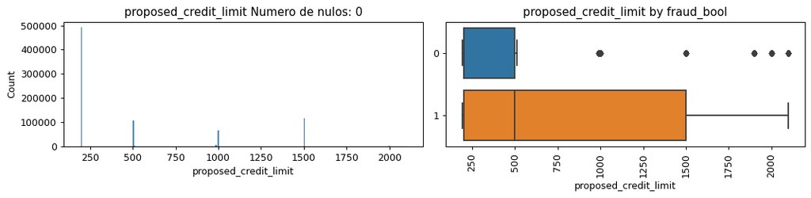

Para el gráfico de proposed_credit_limit de la izq: la moda está en el valor más alto de la izq. Discrimina bastante la variable porque los 0 tienen una distribución con poca desviación.

En cuanto a estos gráficos, en los gráficos de la derecha para las variables continuas, vemos sus datos con respecto a la variable objetivo, mientras que en las categóricas se mira que porcentaje tiene de cada.

Por resaltar alguno de los ejemplos, podemos observar que el credit_risk_score tiene una mayor variabilidad de valores para los ejemplos que muestran fraude que para los que no.

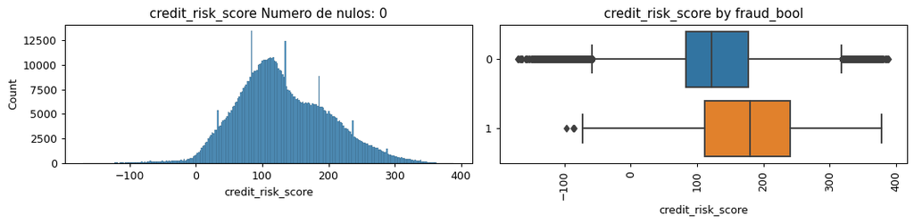

#### Tratamiento de las variables continuas

Primero, se deshace la transformación que hse hizo antes para que funcionasen los gráficos.

```python
pd_fraud[to_float] = pd_fraud[to_float].astype(int)
```

Cambio de la variable proposed_credit_limit a entero porque estaba como float pero no tenía ningún decimal

```python
pd_fraud['proposed_credit_limit'] = pd_fraud['proposed_credit_limit'].astype(int)
```

```python
list_var_cont = list(pd_fraud.select_dtypes('float').columns)
pd_fraud[list_var_cont] = pd_fraud[list_var_cont].astype(float)
list_var_cont
```

```
['income',
 'session_length_in_minutes',
 'velocity_4w',
 'velocity_24h',
 'velocity_6h',
 'intended_balcon_amount',
 'days_since_request',
 'name_email_similarity']
```

#### Tratamiento de outliers

Los valores outlier se pueden sustituir por la media, mediana, valores extremos (media + 3std o media - 3std). Se ha decidido como primera iteración dejarlos sin sustituir para comprobar como funciona así el modelo.

```python
# Comprobación del número de outliers y el porcentaje de nulos
get_deviation_of_mean_perc(pd_fraud_train, list_var_cont, target='fraud_bool', multiplier=3)
```

|  | 0.0 | 1.0 | variable | sum_outlier_values | porcentaje_sum_null_values |
| --- | --- | --- | --- | --- | --- |
| 0 | 0.979675 | 0.020325 | session_length_in_minutes | 18844 | 0.023555 |
| 1 | 0.997613 | 0.002387 | velocity_24h | 419 | 0.000524 |
| 2 | 0.992804 | 0.007196 | velocity_6h | 3474 | 0.004343 |
| 3 | 0.990102 | 0.009898 | intended_balcon_amount | 15154 | 0.018943 |
| 4 | 0.988379 | 0.011621 | days_since_request | 14199 | 0.017749 |

Se puede observar que no hay un gran efecto en las medias por parte de los outliers.

#### Correlaciones

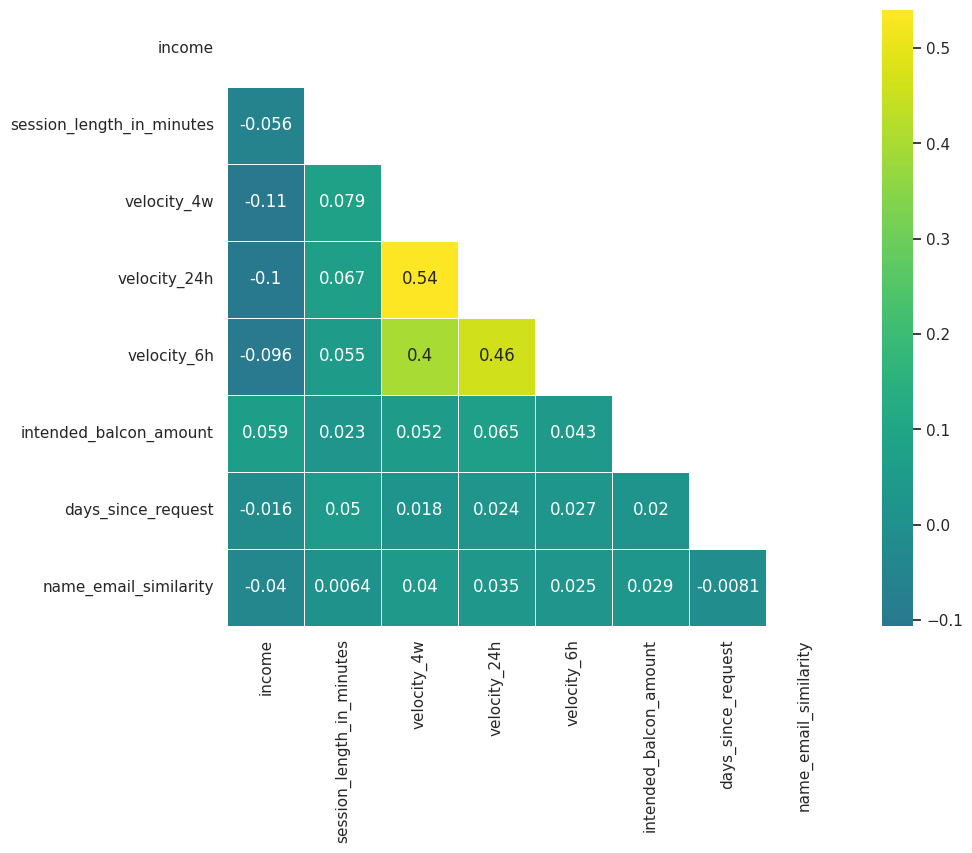

```python
# Gráfico de la matriz de correlaciones
get_corr_matrix(dataset = pd_fraud_train[list_var_cont],
                method='pearson', size_figure=[10,8])
```

Se observa que la correlación más fuerte se da entre las variables de las distintas velocidades.

En algunos algoritmos, como los ensembling de árboles (xgboost, randomforest, lightgbm, catboost, ...) no es necesario eliminar colinealidad entre variables. En otros algoritmos como glm si es necesario eliminar la colinealidad

```python
# Comprobación numérica con threshold
corr = pd_fraud_train[list_var_cont].corr('pearson')
new_corr = corr.abs()
new_corr.loc[:,:] = np.tril(new_corr, k=-1) # below main lower triangle of an array
new_corr = new_corr.stack().to_frame('correlation').reset_index().sort_values(by='correlation', ascending=False)
new_corr[new_corr['correlation']>0.5]
```

|  | level_0 | level_1 | correlation |
| --- | --- | --- | --- |
| 26 | velocity_24h | velocity_4w | 0.539986 |

No hay ninguna variable continua que presente correlación mayor al 60%, y sólo una por encima del 50%, la de velocity_24h con velocity_4w.

#### Tratamiento de valores nulos

¿Son todos los nulos de una clase de la variable objetivo? o tienen el mismo porcentaje de la variable objetivo?

```python
# Número de valores nulos frente a porcentaje
get_percent_null_values_target(pd_fraud_train, list_var_cont, target='fraud_bool')
```

|  | 0.0 | 1.0 | variable | sum_null_values | porcentaje_sum_null_values |
| --- | --- | --- | --- | --- | --- |
| 0 | 0.990724 | 0.009276 | session_length_in_minutes | 1617 | 0.002021 |
| 1 | 0.986885 | 0.013115 | intended_balcon_amount | 594427 | 0.743034 |

Imputaré los valores missing por la mediana de su columna

```python
# Lista de columnas a imputar
columns = ['session_length_in_minutes',
           'current_address_months_count',
           'intended_balcon_amount',
           'prev_address_months_count',
           'bank_months_count',
           'device_distinct_emails_8w'
           ]

# Cambio de nulos por mediana
pd_fraud_train_clean = impute_na(data=pd_fraud_train, columns=columns)
```

Este proceso también se podría realizar con un pipline, lo que evitaría posibles problemas futuros al recibir datos nuevos con valores NA cuando el modelo esté en producción.

```python
# Comprobación
get_percent_null_values_target(pd_fraud_train_clean, list_var_cont, target='fraud_bool')
```

```
No existen variables con valores nulos
```

#### Tratamiento de las variables categóricas

```python
confusion_matrix = pd.crosstab(pd_fraud_train_clean["fraud_bool"], pd_fraud_train_clean["income"])
print(confusion_matrix)
cramers_v(confusion_matrix.values)
```

```
income         0.1    0.2    0.3    0.4    0.5    0.6    0.7     0.8     0.9
fraud_bool
0           125074  55177  40335  64591  44244  88774  83353  116127  173502
1              710    336    263    471    359    797    741    1279    3867
```

```
0.05716388120289282
```

```python
confusion_matrix = pd.crosstab(pd_fraud_train_clean["fraud_bool"], pd_fraud_train_clean["fraud_bool"])
cramers_v(confusion_matrix.values)
```

```
0.9999426978916621
```

```python
confusion_matrix = pd.crosstab(pd_fraud_train_clean["fraud_bool"], pd_fraud_train_clean["housing_status"])
cramers_v(confusion_matrix.values)
```

```
0.11427364004365193
```

#### Tratamiento de valores nulos

En las variables categoricas, los valores nulos se suelen sustituir por una nueva clase: "sin valor" o por la moda. En este caso, sustituyo por 'sin valor'

```python
# Reemplazo de valores NA por 'sin valor' en train
pd_fraud_train_clean[cat_vars] = (
    pd_fraud_train_clean[cat_vars]
        .astype("object")
        .fillna("SIN VALOR")
        .astype("category")
)

# Reemplazo de valores NA por 'sin valor' en test
pd_fraud_test[cat_vars] = (
    pd_fraud_test[cat_vars]
        .astype("object")
        .fillna("SIN VALOR")
        .astype("category")
)
```

#### Guardado de la tabla

```python
write_csv(pd_fraud_train_clean, "data/preprocessed/train_pd_data_preprocessing_missing_outlier.csv")
write_csv(pd_fraud_test, "data/preprocessed/test_pd_data_preprocessing_missing_outlier.csv")
```

```python
print(pd_fraud_train_clean.shape, pd_fraud_test.shape)
```

```
(800000, 32) (200000, 32)
```

Este es el tamaño final después de todo el tratamiento